# Final Progress Memo 2

Data Science 1 with R (STAT 301-1)

Author

Leo McKenna

Published

November 23, 2023

**Github Repo Link**

https://github.com/stat301-1-2023-fall/final-project-1-leomckenna.git

## Load Packages and Data

```r
# Loading package(s)
library(tidyverse)
library(skimr)
#reading in data
nfl_elo_data <- read_csv("data/nfl_elo.csv")
foxboro_weather <- read_csv("data/foxboro_weather_data.csv")
```

## Data Cleaning

```r
#cleaning weather data
foxboro_weather_cleaned <- foxboro_weather |>
  select(-c(1, 16)) |>
  slice(-c(1, 23, 24, 25, 26, 32)) |>
  slice(-27)

foxboro_weather_cleaned <- foxboro_weather |>
  select(-c(1, 16)) |>
  slice(-c(1, 23, 24, 25, 26, 32)) |>
  slice(-27)

foxboro_weather_cleaned <- foxboro_weather_cleaned |>
  setNames(foxboro_weather_cleaned[1, ]) |>
  slice(-1) |>
  pivot_longer(cols = -c(Year, Annual), names_to = "Month", values_to = "Value") |>
  rename(annual_mean_temp = Annual, monthly_mean_temp = Value)

foxboro_weather_cleaned$monthly_mean_temp[foxboro_weather_cleaned$monthly_mean_temp == "M"] <- NA
foxboro_weather_cleaned$monthly_mean_temp <- as.numeric(foxboro_weather_cleaned$monthly_mean_temp)

foxboro_weather_cleaned <- foxboro_weather_cleaned |>
  group_by(Year)

foxboro_weather_cleaned <- foxboro_weather_cleaned |>
  rename_all(tolower)

foxboro_weather_cleaned
```

```
# A tibble: 300 × 4
# Groups:   year [24]
   year  annual_mean_temp month monthly_mean_temp
   <chr> <chr>            <chr>             <dbl>
 1 2000  49.3             Jan                NA
 2 2000  49.3             Feb                30.9
 3 2000  49.3             Mar                NA
 4 2000  49.3             Apr                NA
 5 2000  49.3             May                56.1
 6 2000  49.3             Jun                NA
 7 2000  49.3             Jul                68.5
 8 2000  49.3             Aug                NA
 9 2000  49.3             Sep                61.8
10 2000  49.3             Oct                51.8
# ℹ 290 more rows
```

```r
#filtering elo data and getting rid of unnecessary teams
pats_elo_data <- nfl_elo_data |>
  filter(season >= 2000, team1 == "NE" | team2 == "NE") |>
  mutate(winner = case_when(score1 > score2 ~ team1,
                            score2 > score1 ~ team2,
                            TRUE ~ "Tie")) |>
  select(date, season, winner, everything())

pats_elo_data <- pats_elo_data |>
  filter(team1 == "NE" | team2 == "NE") |>
  mutate(
    team = if_else(team1 == "NE", team1, team2),
    elo_pre = if_else(team1 == "NE", elo1_pre, elo2_pre),
    elo_prob = if_else(team1 == "NE", elo_prob1, elo_prob2),
    elo_post = if_else(team1 == "NE", elo1_post, elo2_post),
    qbelo_pre = if_else(team1 == "NE", qbelo1_pre, qbelo2_pre),
    qb = if_else(team1 == "NE", qb1, qb2),
    qb_value_pre = if_else(team1 == "NE", qb1_value_pre, qb2_value_pre),
    qb_adj = if_else(team1 == "NE", qb1_adj, qb2_adj),
    qbelo_prob = if_else(team1 == "NE", qbelo_prob1, qbelo_prob2),
    qb_game_value = if_else(team1 == "NE", qb1_game_value, qb2_game_value),
    qb_value_post = if_else(team1 == "NE", qb1_value_post, qb2_value_post),
    qbelo_post = if_else(team1 == "NE", qbelo1_post, qbelo2_post)
  ) |>
  select(date, season, neutral, playoff, team, elo_pre, elo_prob, elo_post,
         qbelo_pre, qb, qb_value_pre, qb_adj, qbelo_prob, qb_game_value,
         qb_value_post, qbelo_post, quality, importance, total_rating, score1, score2, winner, playoff)

#Adding monthly data to pats elo data to so I can analyze using monthly weather trends

monthly_pats_elo <- pats_elo_data |>
  mutate(season = as.character(season),
         year = year(date),
         month = month(date),
         day = day(date)) |>
  select(-c(1, 5)) |>
  relocate(year, month, day, winner) |>
  group_by(year, month, season, winner, playoff) |>
  mutate(wins_per_month = sum(winner == "NE")) |>
  group_by(year, month, season) |>
  mutate(elo_pre_per_month = mean(elo_pre),
         elo_post_per_month = mean(elo_post)) |>
  ungroup() |>
  relocate(wins_per_month, elo_pre_per_month, elo_post_per_month)

pats_elo_data
```

```
# A tibble: 412 × 22
   date       season neutral playoff team  elo_pre elo_prob elo_post qbelo_pre
   <date>      <dbl>   <dbl> <chr>   <chr>   <dbl>    <dbl>    <dbl>     <dbl>
 1 2000-09-03   2000       0 <NA>    NE      1500.    0.486    1482.     1485.
 2 2000-09-11   2000       0 <NA>    NE      1482.    0.277    1479.     1470.
 3 2000-09-17   2000       0 <NA>    NE      1479.    0.394    1462.     1466.
 4 2000-09-24   2000       0 <NA>    NE      1462.    0.299    1450.     1446.
 5 2000-10-01   2000       0 <NA>    NE      1450.    0.252    1488.     1434.
 6 2000-10-08   2000       0 <NA>    NE      1488.    0.436    1513.     1476.
 7 2000-10-15   2000       0 <NA>    NE      1513.    0.502    1484.     1506.
 8 2000-10-22   2000       0 <NA>    NE      1484.    0.266    1474.     1474.
 9 2000-11-05   2000       0 <NA>    NE      1474.    0.468    1461.     1466.
10 2000-11-12   2000       0 <NA>    NE      1461.    0.699    1428.     1452.
# ℹ 402 more rows
# ℹ 13 more variables: qb <chr>, qb_value_pre <dbl>, qb_adj <dbl>,
#   qbelo_prob <dbl>, qb_game_value <dbl>, qb_value_post <dbl>,
#   qbelo_post <dbl>, quality <dbl>, importance <dbl>, total_rating <dbl>,
#   score1 <dbl>, score2 <dbl>, winner <chr>
```

## Joining Data

```r
#searching for intersecting names
names(pats_elo_data) |>
  intersect(names(foxboro_weather_cleaned))
```

```
character(0)
```

```r
#joining data

foxboro_data <- monthly_pats_elo |>
  mutate(year = as.character(year)) |>
  mutate(month = month.abb[month]) |>
  mutate(wins_per_month = as_factor(wins_per_month)) |>
  left_join(foxboro_weather_cleaned, by = join_by(year, month)) |>
  group_by(year, month) |>
  filter(is.na(playoff))
```

## Searching for Trends

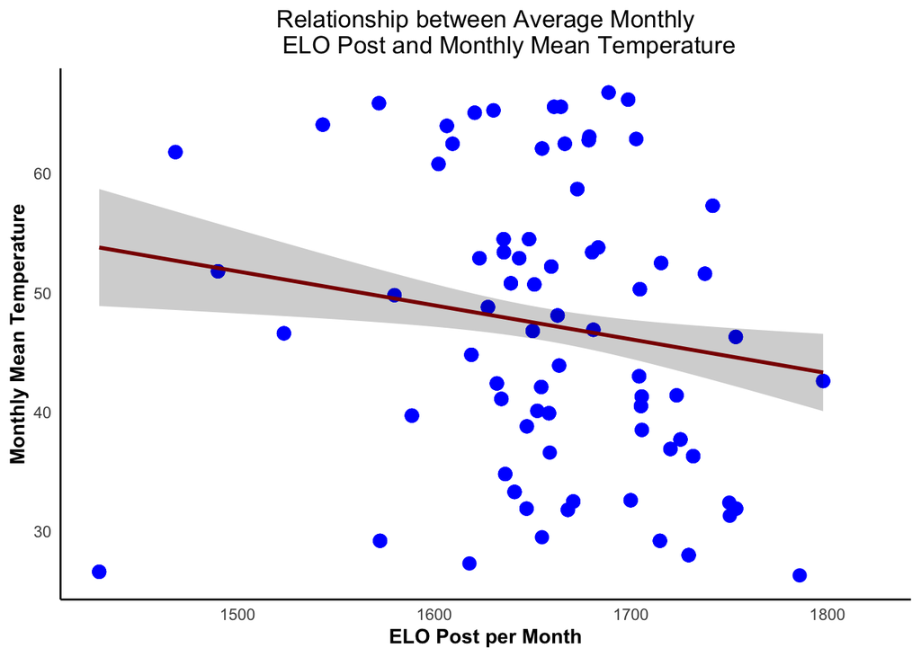

```r
foxboro_data |>
  ggplot(aes(x = elo_post_per_month, y = monthly_mean_temp)) +
  geom_point(color = "blue", size = 3) +
  geom_smooth(method = lm, color = "darkred", fill = "black", alpha = 0.2) +
  labs(x = "ELO Post per Month", y = "Monthly Mean Temperature", title = "Relationship between Average Monthly
       ELO Post and Monthly Mean Temperature") +
  theme_minimal() +
  theme(
    panel.grid = element_blank(),
    axis.line = element_line(color = "black"),
    text = element_text(color = "black"),
    plot.title = element_text(hjust = 0.5),
    axis.title = element_text(face = "bold"),
    legend.position = "top"
  )
```

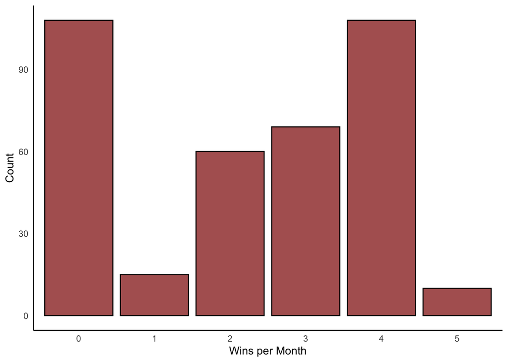

```r
foxboro_data  |>
  ggplot(aes(x = wins_per_month)) +
  geom_bar(fill = "darkred", color = "black", alpha = 0.7) +
  labs(x = "Wins per Month", y = "Count") +
  theme_minimal() +
  theme(
    panel.grid = element_blank(),
    axis.line = element_line(color = "black"),
    text = element_text(color = "black")
  )
```

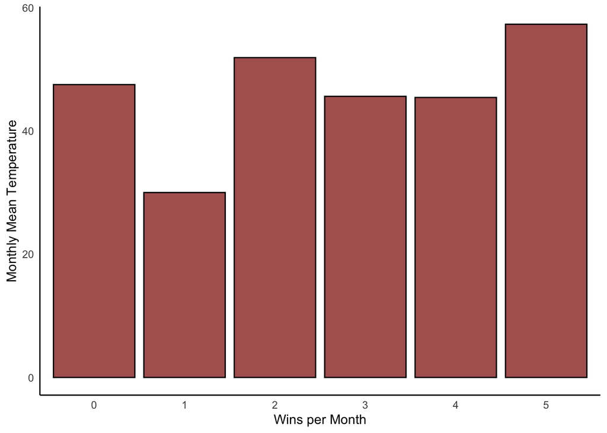

```r
foxboro_data |>
  ggplot(aes(x = wins_per_month, y = monthly_mean_temp)) +
  geom_bar(stat = "summary", fun = "mean", fill = "darkred", color = "black", alpha = 0.7) +
  labs(x = "Wins per Month", y = "Monthly Mean Temperature") +
  theme_minimal() +
  theme(
    panel.grid = element_blank(),
    axis.line = element_line(color = "black"),
    text = element_text(color = "black")
  )
```

Admittedly, I cant make fully correct deductions from these graphs as I’ll share in the next part of this qmd, but these graphs do show us a few interesting things. Firstly, the relationship between Average Monthly ELO Post and Monthly Mean Temperature is negative. The line of best fit slopes downward, meaning that there could be an inverse relationship between the two. This would fit the prevailing theory that in colder temperatures the Patriots excel. The graphs for wins per month show us something interesting as well. Obviously, because there have been both periods where the Patriots were very good and very bad, there are spikes at 0 and 4 wins per month. This corresponds to winning none or, in most cases all of the games in a month. For the graph with wins per month and monthly mean temperature, I was attempting to compare the height of the bars to see if there’s a noticeable difference in mean temperatures for different levels of wins per month. We can see, interestingly, there seems to be a vague trend upwards here which would contradict our previous findings. I think in order to get a more conclusive picture, I’ll have to consider more variables and consider a few next steps.

## Next Steps

I think my next steps will be to look at other weather variables from Foxboro during this time and to analyze whether the weather makes a difference or not in bigger games such as the playoffs. Also, unfortunately I realized to late that I hadn’t accounted for the fact that some weeks, the games were not played in foxboro meaning the temperature data is wrong. My plan for this is to incorporate a different FiveThirtyEight data set which has location data for these games, and account only for home games.